# DataVisualization

# Q9: Find any relationship between history and resposne

```
RESPONSE
0    AxesSubplot(0.125,0.125;0.775x0.755)
1    AxesSubplot(0.125,0.125;0.775x0.755)
Name: HISTORY, dtype: object
```

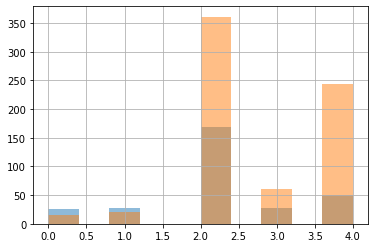

```python
#1st chart
df.groupby("RESPONSE").HISTORY.hist(alpha=0.5)
```

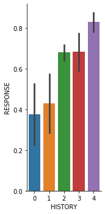

```python
sns.catplot("HISTORY", "RESPONSE", data=df, aspect=.5, kind='bar')
```

People with history of 2, 3, 4, seem to have a higher rate of paying back their loans

# Q10: Relationship between real estate and response

```
RESPONSE
0    AxesSubplot(0.125,0.125;0.775x0.755)
1    AxesSubplot(0.125,0.125;0.775x0.755)
Name: REAL_ESTATE, dtype: object
```

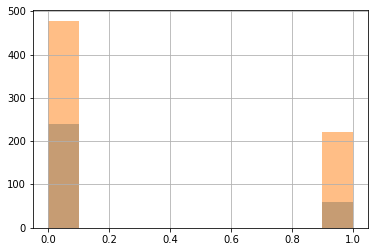

```python
df.groupby("RESPONSE").REAL_ESTATE.hist(alpha=0.5)
```

Those with real estate seem to be more likely to pay off their loans

# Q11: Relationship between Savings account and response

```
RESPONSE
0    AxesSubplot(0.125,0.125;0.775x0.755)
1    AxesSubplot(0.125,0.125;0.775x0.755)
Name: SAV_ACCT, dtype: object
```

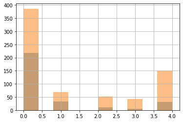

```python
df.groupby("RESPONSE").SAV_ACCT.hist(alpha=0.5)
```

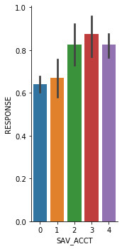

```python
sns.catplot("SAV_ACCT", "RESPONSE", data=df, aspect=.5, kind='bar')
```

Those with saving accounts with higher amounts have higher response rates

# Q12: Who is likely to pay back? Who is not likely to pay back?

From the data visualizations I have created, I found that Duration, Check account, History, Amount, Real Estate, Savings account, and employment seem to be the variables that affect RESPONSE the most.

Those who owned real estate were likely to pay back their loan as they would be able to earn money consistently that way. In addition, those with large amounts of money in their savings account were able to pay back on their loans around 80% of the time.

Other variables in the dataset were not seen as significant in determining the RESPONSE variable, and focusing on these things: the length of the time to pay back the loan, the amount of the loan, current balance in account, their credit history, and their checking account status, it is possible to determine who will pay back their loan or not.